# Part I - Ford GoBike System Data Exploration

## I. Introduction

Data analysis has used many tools to find answers to business problems and questions, one of these most widely used tools is data visualization, it is very effective for data exploration and for analysis. explanation of the results. With the right graphic and an appropriate story, you can get your point across to anyone.

In this notebook, we'll explore data from a bike-sharing system covering the greater San Francisco Bay Area. The data is known as **Ford GoBike System Data** and can be downloaded from [Kaggle](https://www.kaggle.com/datasets/ahmedmohameddawoud/ford-gobike-system-data). Each line contains various information about an individual trip such as duration, departure and arrival station, bike, etc. Brief Description of Data Each ride is anonymized and includes:

- Trip Duration (seconds)
- Start Time and Date
- End Time and Date
- Start Station ID
- Start Station Name
- Start Station Latitude
- Start Station Longitude
- End Station ID
- End Station Name
- End Station Latitude
- End Station Longitude
- Bike ID
- User Type (Subscriber or Customer — “Subscriber” = Member or “Customer” = Casual)
- Member Year of Birth
- Member Gender

## II. Preliminary Wrangling

**Tip:** You may need to change this notebook to trusted pad by clicking on the top right button, this will help you view the map plot generated later. Also consider installing the following libraries:

```
!pip install reverse_geocoder
!pip install folium
!pip install squarify
```

```python
# import all packages and set plots to be embedded inline
import numpy as np
import pandas as pd
import matplotlib
import matplotlib.pyplot as plt
import seaborn as sb
from IPython.display import Markdown, display
import reverse_geocoder as rg
import folium
import squarify

%matplotlib inline
```

### 1. Data Inspection

Let's start by loading the dataset for investigation:

```python
dataset_path = "201902-fordgobike-tripdata.csv"

df = pd.read_csv(dataset_path)

print("Number of records: ", df.shape[0])
print("Number of columns: ", df.shape[1])
df
```

```
Number of records:  183412
Number of columns:  16
```

|  | duration_sec | start_time | end_time | start_station_id | start_station_name | start_station_latitude | start_station_longitude | end_station_id | end_station_name | end_station_latitude | end_station_longitude | bike_id | user_type | member_birth_year | member_gender | bike_share_for_all_trip |
| --- | --- | --- | --- | --- | --- | --- | --- | --- | --- | --- | --- | --- | --- | --- | --- | --- |
| 0 | 52185 | 2019-02-28 17:32:10.1450 | 2019-03-01 08:01:55.9750 | 21.0 | Montgomery St BART Station (Market St at 2nd St) | 37.789625 | -122.400811 | 13.0 | Commercial St at Montgomery St | 37.794231 | -122.402923 | 4902 | Customer | 1984.0 | Male | No |
| 1 | 42521 | 2019-02-28 18:53:21.7890 | 2019-03-01 06:42:03.0560 | 23.0 | The Embarcadero at Steuart St | 37.791464 | -122.391034 | 81.0 | Berry St at 4th St | 37.775880 | -122.393170 | 2535 | Customer | NaN | NaN | No |
| 2 | 61854 | 2019-02-28 12:13:13.2180 | 2019-03-01 05:24:08.1460 | 86.0 | Market St at Dolores St | 37.769305 | -122.426826 | 3.0 | Powell St BART Station (Market St at 4th St) | 37.786375 | -122.404904 | 5905 | Customer | 1972.0 | Male | No |
| 3 | 36490 | 2019-02-28 17:54:26.0100 | 2019-03-01 04:02:36.8420 | 375.0 | Grove St at Masonic Ave | 37.774836 | -122.446546 | 70.0 | Central Ave at Fell St | 37.773311 | -122.444293 | 6638 | Subscriber | 1989.0 | Other | No |
| 4 | 1585 | 2019-02-28 23:54:18.5490 | 2019-03-01 00:20:44.0740 | 7.0 | Frank H Ogawa Plaza | 37.804562 | -122.271738 | 222.0 | 10th Ave at E 15th St | 37.792714 | -122.248780 | 4898 | Subscriber | 1974.0 | Male | Yes |
| 5 | 1793 | 2019-02-28 23:49:58.6320 | 2019-03-01 00:19:51.7600 | 93.0 | 4th St at Mission Bay Blvd S | 37.770407 | -122.391198 | 323.0 | Broadway at Kearny | 37.798014 | -122.405950 | 5200 | Subscriber | 1959.0 | Male | No |
| 6 | 1147 | 2019-02-28 23:55:35.1040 | 2019-03-01 00:14:42.5880 | 300.0 | Palm St at Willow St | 37.317298 | -121.884995 | 312.0 | San Jose Diridon Station | 37.329732 | -121.901782 | 3803 | Subscriber | 1983.0 | Female | No |
| 7 | 1615 | 2019-02-28 23:41:06.7660 | 2019-03-01 00:08:02.7560 | 10.0 | Washington St at Kearny St | 37.795393 | -122.404770 | 127.0 | Valencia St at 21st St | 37.756708 | -122.421025 | 6329 | Subscriber | 1989.0 | Male | No |
| 8 | 1570 | 2019-02-28 23:41:48.7900 | 2019-03-01 00:07:59.7150 | 10.0 | Washington St at Kearny St | 37.795393 | -122.404770 | 127.0 | Valencia St at 21st St | 37.756708 | -122.421025 | 6548 | Subscriber | 1988.0 | Other | No |
| 9 | 1049 | 2019-02-28 23:49:47.6990 | 2019-03-01 00:07:17.0250 | 19.0 | Post St at Kearny St | 37.788975 | -122.403452 | 121.0 | Mission Playground | 37.759210 | -122.421339 | 6488 | Subscriber | 1992.0 | Male | No |
| 10 | 458 | 2019-02-28 23:57:57.2110 | 2019-03-01 00:05:35.4350 | 370.0 | Jones St at Post St | 37.787327 | -122.413278 | 43.0 | San Francisco Public Library (Grove St at Hyde... | 37.778768 | -122.415929 | 5318 | Subscriber | 1996.0 | Female | Yes |
| 11 | 506 | 2019-02-28 23:56:55.5400 | 2019-03-01 00:05:21.7330 | 44.0 | Civic Center/UN Plaza BART Station (Market St ... | 37.781074 | -122.411738 | 343.0 | Bryant St at 2nd St | 37.783172 | -122.393572 | 5848 | Subscriber | 1993.0 | Male | No |
| 12 | 1176 | 2019-02-28 23:45:12.6510 | 2019-03-01 00:04:49.1840 | 127.0 | Valencia St at 21st St | 37.756708 | -122.421025 | 323.0 | Broadway at Kearny | 37.798014 | -122.405950 | 5328 | Customer | 1990.0 | Male | No |
| 13 | 915 | 2019-02-28 23:49:06.0620 | 2019-03-01 00:04:21.8670 | 252.0 | Channing Way at Shattuck Ave | 37.865847 | -122.267443 | 244.0 | Shattuck Ave at Hearst Ave | 37.873676 | -122.268487 | 5101 | Subscriber | NaN | NaN | No |
| 14 | 395 | 2019-02-28 23:56:26.8480 | 2019-03-01 00:03:01.9470 | 243.0 | Bancroft Way at College Ave | 37.869360 | -122.254337 | 252.0 | Channing Way at Shattuck Ave | 37.865847 | -122.267443 | 4786 | Subscriber | 1988.0 | Male | No |
| 15 | 208 | 2019-02-28 23:59:18.5480 | 2019-03-01 00:02:47.2280 | 349.0 | Howard St at Mary St | 37.781010 | -122.405666 | 60.0 | 8th St at Ringold St | 37.774520 | -122.409449 | 6361 | Subscriber | 1993.0 | Male | Yes |
| 16 | 548 | 2019-02-28 23:50:41.6070 | 2019-02-28 23:59:49.9530 | 131.0 | 22nd St at Dolores St | 37.755000 | -122.425728 | 71.0 | Broderick St at Oak St | 37.773063 | -122.439078 | 6572 | Subscriber | 1981.0 | Male | No |
| 17 | 674 | 2019-02-28 23:48:25.0950 | 2019-02-28 23:59:40.0920 | 74.0 | Laguna St at Hayes St | 37.776435 | -122.426244 | 336.0 | Potrero Ave and Mariposa St | 37.763281 | -122.407377 | 5343 | Subscriber | 1975.0 | Male | No |
| 18 | 557 | 2019-02-28 23:49:01.8510 | 2019-02-28 23:58:19.8090 | 321.0 | 5th St at Folsom | 37.780146 | -122.403071 | 75.0 | Market St at Franklin St | 37.773793 | -122.421239 | 5854 | Subscriber | 1990.0 | Male | No |
| 19 | 874 | 2019-02-28 23:43:05.1830 | 2019-02-28 23:57:39.7960 | 180.0 | Telegraph Ave at 23rd St | 37.812678 | -122.268773 | 180.0 | Telegraph Ave at 23rd St | 37.812678 | -122.268773 | 5629 | Customer | 1978.0 | Male | No |
| 20 | 417 | 2019-02-28 23:50:38.2390 | 2019-02-28 23:57:35.8520 | 72.0 | Page St at Scott St | 37.772406 | -122.435650 | 107.0 | 17th St at Dolores St | 37.763015 | -122.426497 | 4999 | Subscriber | 1983.0 | Male | No |
| 21 | 414 | 2019-02-28 23:50:26.8790 | 2019-02-28 23:57:21.1300 | 163.0 | Lake Merritt BART Station | 37.797320 | -122.265320 | 221.0 | 6th Ave at E 12th St (Temporary Location) | 37.794396 | -122.253842 | 6007 | Subscriber | 1984.0 | Male | Yes |
| 22 | 743 | 2019-02-28 23:44:56.4390 | 2019-02-28 23:57:20.2120 | 370.0 | Jones St at Post St | 37.787327 | -122.413278 | 52.0 | McAllister St at Baker St | 37.777416 | -122.441838 | 5479 | Subscriber | 1991.0 | Female | No |
| 23 | 367 | 2019-02-28 23:51:06.0140 | 2019-02-28 23:57:13.3120 | 243.0 | Bancroft Way at College Ave | 37.869360 | -122.254337 | 269.0 | Telegraph Ave at Carleton St | 37.862320 | -122.258801 | 1804 | Subscriber | 1997.0 | Female | No |
| 24 | 252 | 2019-02-28 23:52:51.1640 | 2019-02-28 23:57:03.9760 | 190.0 | West St at 40th St | 37.830223 | -122.270950 | 189.0 | Genoa St at 55th St | 37.839649 | -122.271756 | 5678 | Subscriber | 1975.0 | Male | No |
| 25 | 360 | 2019-02-28 23:50:31.4310 | 2019-02-28 23:56:31.8910 | 163.0 | Lake Merritt BART Station | 37.797320 | -122.265320 | 196.0 | Grand Ave at Perkins St | 37.808894 | -122.256460 | 6240 | Subscriber | 1986.0 | Male | No |
| 26 | 385 | 2019-02-28 23:49:24.3990 | 2019-02-28 23:55:50.2840 | 6.0 | The Embarcadero at Sansome St | 37.804770 | -122.403234 | 15.0 | San Francisco Ferry Building (Harry Bridges Pl... | 37.795392 | -122.394203 | 6531 | Customer | 2000.0 | Male | No |
| 27 | 408 | 2019-02-28 23:48:08.2820 | 2019-02-28 23:54:56.9300 | 78.0 | Folsom St at 9th St | 37.773717 | -122.411647 | 78.0 | Folsom St at 9th St | 37.773717 | -122.411647 | 5410 | Subscriber | 1982.0 | Male | No |
| 28 | 650 | 2019-02-28 23:43:27.5030 | 2019-02-28 23:54:18.4510 | 258.0 | University Ave at Oxford St | 37.872355 | -122.266447 | 263.0 | Channing Way at San Pablo Ave | 37.862827 | -122.290230 | 4784 | Customer | NaN | NaN | No |
| 29 | 629 | 2019-02-28 23:43:48.6580 | 2019-02-28 23:54:18.2540 | 258.0 | University Ave at Oxford St | 37.872355 | -122.266447 | 263.0 | Channing Way at San Pablo Ave | 37.862827 | -122.290230 | 363 | Subscriber | 1995.0 | Male | No |
| ... | ... | ... | ... | ... | ... | ... | ... | ... | ... | ... | ... | ... | ... | ... | ... | ... |
| 183382 | 961 | 2019-02-01 00:38:29.9040 | 2019-02-01 00:54:31.7320 | 95.0 | Sanchez St at 15th St | 37.766219 | -122.431060 | 324.0 | Union Square (Powell St at Post St) | 37.788300 | -122.408531 | 1565 | Subscriber | 1988.0 | Male | No |
| 183383 | 434 | 2019-02-01 00:47:11.6530 | 2019-02-01 00:54:26.3050 | 274.0 | Oregon St at Adeline St | 37.857567 | -122.267558 | 244.0 | Shattuck Ave at Hearst Ave | 37.873676 | -122.268487 | 4541 | Customer | 1997.0 | Male | No |
| 183384 | 184 | 2019-02-01 00:50:41.5790 | 2019-02-01 00:53:46.1240 | 316.0 | San Salvador St at 1st St | 37.330165 | -121.885831 | 298.0 | Oak St at 1st St | 37.322125 | -121.881090 | 4044 | Subscriber | 1991.0 | Male | No |
| 183385 | 400 | 2019-02-01 00:46:47.2760 | 2019-02-01 00:53:27.5960 | 220.0 | San Pablo Ave at MLK Jr Way | 37.811351 | -122.273422 | 337.0 | Webster St at 19th St | 37.806970 | -122.266588 | 3487 | Subscriber | 1945.0 | Male | Yes |
| 183386 | 425 | 2019-02-01 00:42:20.4720 | 2019-02-01 00:49:25.5150 | 239.0 | Bancroft Way at Telegraph Ave | 37.868813 | -122.258764 | 245.0 | Downtown Berkeley BART | 37.870139 | -122.268422 | 1377 | Subscriber | 1998.0 | Male | Yes |
| 183387 | 598 | 2019-02-01 00:39:12.6840 | 2019-02-01 00:49:10.7910 | 239.0 | Bancroft Way at Telegraph Ave | 37.868813 | -122.258764 | 245.0 | Downtown Berkeley BART | 37.870139 | -122.268422 | 2055 | Subscriber | 1999.0 | Male | Yes |
| 183388 | 490 | 2019-02-01 00:39:53.1120 | 2019-02-01 00:48:03.3380 | 61.0 | Howard St at 8th St | 37.776513 | -122.411306 | 81.0 | Berry St at 4th St | 37.775880 | -122.393170 | 5411 | Subscriber | 1927.0 | Male | No |
| 183389 | 184 | 2019-02-01 00:43:56.5560 | 2019-02-01 00:47:01.0090 | 66.0 | 3rd St at Townsend St | 37.778742 | -122.392741 | 47.0 | 4th St at Harrison St | 37.780955 | -122.399749 | 4960 | Subscriber | 1985.0 | Other | No |
| 183390 | 232 | 2019-02-01 00:40:00.0350 | 2019-02-01 00:43:52.8800 | 239.0 | Bancroft Way at Telegraph Ave | 37.868813 | -122.258764 | 266.0 | Parker St at Fulton St | 37.862464 | -122.264791 | 3756 | Subscriber | 1999.0 | Male | No |
| 183391 | 269 | 2019-02-01 00:37:47.5270 | 2019-02-01 00:42:17.0600 | 119.0 | 18th St at Noe St | 37.761047 | -122.432642 | 85.0 | Church St at Duboce Ave | 37.770083 | -122.429156 | 5540 | Subscriber | 1980.0 | Male | Yes |
| 183392 | 1289 | 2019-02-01 00:19:45.6410 | 2019-02-01 00:41:15.5580 | 8.0 | The Embarcadero at Vallejo St | 37.799953 | -122.398525 | 350.0 | 8th St at Brannan St | 37.771431 | -122.405787 | 3506 | Subscriber | 1993.0 | Male | No |
| 183393 | 155 | 2019-02-01 00:37:26.3680 | 2019-02-01 00:40:01.5760 | 116.0 | Mississippi St at 17th St | 37.764802 | -122.394771 | 93.0 | 4th St at Mission Bay Blvd S | 37.770407 | -122.391198 | 5406 | Subscriber | 1985.0 | Male | No |
| 183394 | 720 | 2019-02-01 00:27:33.8340 | 2019-02-01 00:39:34.2330 | 26.0 | 1st St at Folsom St | 37.787290 | -122.394380 | 96.0 | Dolores St at 15th St | 37.766210 | -122.426614 | 5331 | Subscriber | 1975.0 | Male | No |
| 183395 | 95 | 2019-02-01 00:37:23.1150 | 2019-02-01 00:38:58.3460 | 276.0 | Julian St at The Alameda | 37.332233 | -121.912517 | 277.0 | Morrison Ave at Julian St | 37.333658 | -121.908586 | 4299 | Subscriber | 1993.0 | Male | Yes |
| 183396 | 576 | 2019-02-01 00:27:06.5030 | 2019-02-01 00:36:43.4520 | 181.0 | Grand Ave at Webster St | 37.811377 | -122.265192 | 212.0 | Mosswood Park | 37.824893 | -122.260437 | 3561 | Subscriber | 1991.0 | Male | Yes |
| 183397 | 438 | 2019-02-01 00:28:56.1010 | 2019-02-01 00:36:14.5340 | 62.0 | Victoria Manalo Draves Park | 37.777791 | -122.406432 | 59.0 | S Van Ness Ave at Market St | 37.774814 | -122.418954 | 5531 | Subscriber | 1988.0 | Male | No |
| 183398 | 1019 | 2019-02-01 00:16:59.1550 | 2019-02-01 00:33:58.5900 | 339.0 | Jackson St at 11th St | 37.800002 | -122.266438 | 46.0 | San Antonio Park | 37.790140 | -122.242373 | 3233 | Subscriber | 1982.0 | Male | No |
| 183399 | 958 | 2019-02-01 00:12:24.2470 | 2019-02-01 00:28:22.7380 | 67.0 | San Francisco Caltrain Station 2 (Townsend St... | 37.776639 | -122.395526 | 58.0 | Market St at 10th St | 37.776619 | -122.417385 | 3392 | Subscriber | 1993.0 | Male | No |
| 183400 | 250 | 2019-02-01 00:23:52.6110 | 2019-02-01 00:28:02.6790 | 356.0 | Valencia St at Clinton Park | 37.769188 | -122.422285 | 58.0 | Market St at 10th St | 37.776619 | -122.417385 | 4962 | Subscriber | 1984.0 | Male | No |
| 183401 | 383 | 2019-02-01 00:16:48.0620 | 2019-02-01 00:23:11.2010 | 186.0 | Lakeside Dr at 14th St | 37.801319 | -122.262642 | 181.0 | Grand Ave at Webster St | 37.811377 | -122.265192 | 4505 | Subscriber | 1991.0 | Male | Yes |
| 183402 | 122 | 2019-02-01 00:17:32.2580 | 2019-02-01 00:19:34.9380 | 119.0 | 18th St at Noe St | 37.761047 | -122.432642 | 120.0 | Mission Dolores Park | 37.761420 | -122.426435 | 4326 | Subscriber | NaN | NaN | No |
| 183403 | 249 | 2019-02-01 00:15:12.0670 | 2019-02-01 00:19:21.6990 | 256.0 | Hearst Ave at Euclid Ave | 37.875112 | -122.260553 | 247.0 | Fulton St at Bancroft Way | 37.867789 | -122.265896 | 4642 | Subscriber | 2000.0 | Male | No |
| 183404 | 256 | 2019-02-01 00:12:50.5540 | 2019-02-01 00:17:07.3620 | 241.0 | Ashby BART Station | 37.852477 | -122.270213 | 248.0 | Telegraph Ave at Ashby Ave | 37.855956 | -122.259795 | 4845 | Subscriber | 1980.0 | Male | Yes |
| 183405 | 111 | 2019-02-01 00:14:49.8740 | 2019-02-01 00:16:41.3010 | 324.0 | Union Square (Powell St at Post St) | 37.788300 | -122.408531 | 19.0 | Post St at Kearny St | 37.788975 | -122.403452 | 4832 | Subscriber | 1984.0 | Male | No |
| 183406 | 706 | 2019-02-01 00:04:40.6160 | 2019-02-01 00:16:27.0800 | 138.0 | Jersey St at Church St | 37.750900 | -122.427411 | 78.0 | Folsom St at 9th St | 37.773717 | -122.411647 | 5017 | Subscriber | 1988.0 | Male | No |
| 183407 | 480 | 2019-02-01 00:04:49.7240 | 2019-02-01 00:12:50.0340 | 27.0 | Beale St at Harrison St | 37.788059 | -122.391865 | 324.0 | Union Square (Powell St at Post St) | 37.788300 | -122.408531 | 4832 | Subscriber | 1996.0 | Male | No |
| 183408 | 313 | 2019-02-01 00:05:34.7440 | 2019-02-01 00:10:48.5020 | 21.0 | Montgomery St BART Station (Market St at 2nd St) | 37.789625 | -122.400811 | 66.0 | 3rd St at Townsend St | 37.778742 | -122.392741 | 4960 | Subscriber | 1984.0 | Male | No |
| 183409 | 141 | 2019-02-01 00:06:05.5490 | 2019-02-01 00:08:27.2200 | 278.0 | The Alameda at Bush St | 37.331932 | -121.904888 | 277.0 | Morrison Ave at Julian St | 37.333658 | -121.908586 | 3824 | Subscriber | 1990.0 | Male | Yes |
| 183410 | 139 | 2019-02-01 00:05:34.3600 | 2019-02-01 00:07:54.2870 | 220.0 | San Pablo Ave at MLK Jr Way | 37.811351 | -122.273422 | 216.0 | San Pablo Ave at 27th St | 37.817827 | -122.275698 | 5095 | Subscriber | 1988.0 | Male | No |
| 183411 | 271 | 2019-02-01 00:00:20.6360 | 2019-02-01 00:04:52.0580 | 24.0 | Spear St at Folsom St | 37.789677 | -122.390428 | 37.0 | 2nd St at Folsom St | 37.785000 | -122.395936 | 1057 | Subscriber | 1989.0 | Male | No |

183412 rows × 16 columns

The dataset contains information on 183,412 trips divided into 16 different columns. Most of the features describe the ride on itself while only three of them present information about the user (user_type, member_birth_year, member_gender).

At first glance, we may be dealing with missing values (this mostly shows up for the birth year and gender columns) and the wrong data type for station IDs. Otherwise, the data looks good to work with.

Let's take a deep look into the dataset:

```python
# overview of the composition of data
df.info()
```

```
<class 'pandas.core.frame.DataFrame'>
RangeIndex: 183412 entries, 0 to 183411
Data columns (total 16 columns):
duration_sec               183412 non-null int64
start_time                 183412 non-null object
end_time                   183412 non-null object
start_station_id           183215 non-null float64
start_station_name         183215 non-null object
start_station_latitude     183412 non-null float64
start_station_longitude    183412 non-null float64
end_station_id             183215 non-null float64
end_station_name           183215 non-null object
end_station_latitude       183412 non-null float64
end_station_longitude      183412 non-null float64
bike_id                    183412 non-null int64
user_type                  183412 non-null object
member_birth_year          175147 non-null float64
member_gender              175147 non-null object
bike_share_for_all_trip    183412 non-null object
dtypes: float64(7), int64(2), object(7)
memory usage: 22.4+ MB
```

A quick look at the data structure reveals:

- The columns that indicate the start and end times of trips are of the object type.
- Missing information on departure and/or arrival stations for some recordings.

The next thing I'm going to do is show some statistics and the data distribution of the columns:

```python
# numeric columns
num_cols = ['duration_sec', 'member_birth_year']
df[num_cols].describe()
```

|  | duration_sec | member_birth_year |
| --- | --- | --- |
| count | 183412.000000 | 175147.000000 |
| mean | 726.078435 | 1984.806437 |
| std | 1794.389780 | 10.116689 |
| min | 61.000000 | 1878.000000 |
| 25% | 325.000000 | 1980.000000 |
| 50% | 514.000000 | 1987.000000 |
| 75% | 796.000000 | 1992.000000 |
| max | 85444.000000 | 2001.000000 |

```python
# datetime columns
dt_cols = ['start_time', 'end_time']
df[dt_cols].apply(pd.to_datetime).describe()
```

|  | start_time | end_time |
| --- | --- | --- |
| count | 183412 | 183412 |
| unique | 183401 | 183397 |
| top | 2019-02-01 13:40:09.492000 | 2019-02-23 12:07:02.570000 |
| freq | 2 | 2 |
| first | 2019-02-01 00:00:20.636000 | 2019-02-01 00:04:52.058000 |
| last | 2019-02-28 23:59:18.548000 | 2019-03-01 08:01:55.975000 |

```python
# printing function
def printmd(string):
    display(Markdown(string))
```

```python
# categorical columns
cat_cols = df.columns.difference(num_cols + dt_cols)
for col in cat_cols:
    printmd(f'Column ==> **{col}**')
    uniq_vals = df[col].nunique()
    printmd(f'Number of unique values: **{uniq_vals}**')
    if uniq_vals > 10:
        print(list(df[col].unique())[:20], list(df[col].unique())[-20:], sep = ' ... ')
        continue
    print(list(df[col].unique()))
```

Column ==> **bike_id**

Number of unique values: **4646**

```
[4902, 2535, 5905, 6638, 4898, 5200, 3803, 6329, 6548, 6488, 5318, 5848, 5328, 5101, 4786, 6361, 6572, 5343, 5854, 5629] ... [2556, 2128, 2526, 4876, 3930, 3160, 3948, 4681, 3409, 556, 1100, 3936, 3966, 4251, 1194, 3395, 2861, 4208, 3655, 5067]
```

Column ==> **bike_share_for_all_trip**

Number of unique values: **2**

```
['No', 'Yes']
```

Column ==> **end_station_id**

Number of unique values: **329**

```
[13.0, 81.0, 3.0, 70.0, 222.0, 323.0, 312.0, 127.0, 121.0, 43.0, 343.0, 244.0, 252.0, 60.0, 71.0, 336.0, 75.0, 180.0, 107.0, 221.0] ... [227.0, 300.0, 306.0, 358.0, 282.0, 287.0, 313.0, 229.0, 237.0, 177.0, 359.0, 288.0, 303.0, 298.0, 234.0, 226.0, 344.0, 224.0, 301.0, 37.0]
```

Column ==> **end_station_latitude**

Number of unique values: **335**

```
[37.794230999999996, 37.775880000000001, 37.786375268615842, 37.773310878897227, 37.7927143, 37.798013643959777, 37.329732, 37.7567083, 37.759210299999992, 37.778767700000003, 37.783171989315306, 37.873676214598248, 37.865846600000005, 37.774520401136854, 37.773062700000004, 37.76328094058097, 37.77…
```

Column ==> **end_station_longitude**

Number of unique values: **335**

```
[-122.402923, -122.39317, -122.40490436553955, -122.44429260492323, -122.24877959999999, -122.40595042705534, -121.90178200000001, -122.421025, -122.42133920000001, -122.41592920000001, -122.39357203245164, -122.26848721504213, -122.26744309999998, -122.4094493687153, -122.4390777, -122.407377362251…
```

Column ==> **end_station_name**

Number of unique values: **329**

```
['Commercial St at Montgomery St', 'Berry St at 4th St', 'Powell St BART Station (Market St at 4th St)', 'Central Ave at Fell St', '10th Ave at E 15th St', 'Broadway at Kearny', 'San Jose Diridon Station', 'Valencia St at 21st St', 'Mission Playground', 'San Francisco Public Library (Grove St at Hyd…
```

Column ==> **member_gender**

Number of unique values: **3**

```
['Male', nan, 'Other', 'Female']
```

Column ==> **start_station_id**

Number of unique values: **329**

```
[21.0, 23.0, 86.0, 375.0, 7.0, 93.0, 300.0, 10.0, 19.0, 370.0, 44.0, 127.0, 252.0, 243.0, 349.0, 131.0, 74.0, 321.0, 180.0, 72.0] ... [222.0, 168.0, 204.0, 189.0, 188.0, 271.0, 221.0, 389.0, 217.0, 228.0, 225.0, 303.0, 209.0, 289.0, 229.0, 301.0, 226.0, 234.0, 224.0, 37.0]
```

Column ==> **start_station_latitude**

Number of unique values: **334**

```
[37.789625399999998, 37.791464000000005, 37.769305299999992, 37.774836294133451, 37.804562354930297, 37.770407399999996, 37.3172979, 37.795392937254526, 37.788975000000001, 37.787326766062399, 37.7810737, 37.7567083, 37.865846600000005, 37.869360299999997, 37.781009717175117, 37.755000260378139, 37.…
```

Column ==> **start_station_longitude**

Number of unique values: **335**

```
[-122.400811, -122.391034, -122.4268256, -122.44654566049576, -122.27173805236816, -122.39119840000002, -121.88499499999999, -122.40477025508881, -122.403452, -122.41327822208405, -122.4117382, -122.421025, -122.26744309999998, -122.25433740000001, -122.40566611289978, -122.42572769522668, -122.4262…
```

Column ==> **start_station_name**

Number of unique values: **329**

```
['Montgomery St BART Station (Market St at 2nd St)', 'The Embarcadero at Steuart St', 'Market St at Dolores St', 'Grove St at Masonic Ave', 'Frank H Ogawa Plaza', '4th St at Mission Bay Blvd S', 'Palm St at Willow St', 'Washington St at Kearny St', 'Post St at Kearny St', 'Jones St at Post St', 'Civ…
```

Column ==> **user_type**

Number of unique values: **2**

```
['Customer', 'Subscriber']
```

A few questions arise after observing the contents of the columns:

- Is it very common to have trips that last about a minute?
- It seems that the names of the stations come from a system that takes its geographic coordinates, is that the reason why there are missing values in the columns of the identifiers and the names of the stations?

We also now know that the data relates to bike rides in February 2019, and that the youngest customer is 18 years old. It's still weird that the oldest customer was born in 1878 (which equals 141 years old at the time of data collection).

The next block of code will print the number of records of bike trips that are less than two minutes long and some of these lines:

```python
temp_df = df.query('duration_sec <= 120')

printmd(f"There are **{temp_df.shape[0]}** of rides lasting less than 2 minutes")
temp_df.sample(20)
```

There are **3159** of rides lasting less than 2 minutes

|  | duration_sec | start_time | end_time | start_station_id | start_station_name | start_station_latitude | start_station_longitude | end_station_id | end_station_name | end_station_latitude | end_station_longitude | bike_id | user_type | member_birth_year | member_gender | bike_share_for_all_trip |
| --- | --- | --- | --- | --- | --- | --- | --- | --- | --- | --- | --- | --- | --- | --- | --- | --- |
| 84080 | 105 | 2019-02-17 19:01:37.0430 | 2019-02-17 19:03:22.4880 | 132.0 | 24th St at Chattanooga St | 37.751819 | -122.426614 | 134.0 | Valencia St at 24th St | 37.752428 | -122.420628 | 5736 | Subscriber | 1976.0 | Male | No |
| 98972 | 107 | 2019-02-14 23:36:40.2670 | 2019-02-14 23:38:28.2030 | 104.0 | 4th St at 16th St | 37.767045 | -122.390833 | 93.0 | 4th St at Mission Bay Blvd S | 37.770407 | -122.391198 | 1406 | Subscriber | 1959.0 | Male | No |
| 103392 | 112 | 2019-02-14 13:21:39.5600 | 2019-02-14 13:23:31.8330 | 239.0 | Bancroft Way at Telegraph Ave | 37.868813 | -122.258764 | 243.0 | Bancroft Way at College Ave | 37.869360 | -122.254337 | 5135 | Subscriber | 1998.0 | Male | Yes |
| 10488 | 108 | 2019-02-27 20:27:11.9240 | 2019-02-27 20:29:00.4630 | 239.0 | Bancroft Way at Telegraph Ave | 37.868813 | -122.258764 | 243.0 | Bancroft Way at College Ave | 37.869360 | -122.254337 | 6385 | Subscriber | 1998.0 | Female | No |
| 38993 | 105 | 2019-02-23 10:43:55.8540 | 2019-02-23 10:45:41.5740 | 112.0 | Harrison St at 17th St | 37.763847 | -122.413004 | 124.0 | 19th St at Florida St | 37.760447 | -122.410807 | 6513 | Subscriber | 1980.0 | Male | No |
| 13683 | 76 | 2019-02-27 15:15:32.9180 | 2019-02-27 15:16:49.4250 | 276.0 | Julian St at The Alameda | 37.332233 | -121.912517 | 277.0 | Morrison Ave at Julian St | 37.333658 | -121.908586 | 4030 | Subscriber | 1993.0 | Male | Yes |
| 88836 | 96 | 2019-02-16 17:16:53.4890 | 2019-02-16 17:18:30.0080 | 108.0 | 16th St Mission BART | 37.764710 | -122.419957 | 108.0 | 16th St Mission BART | 37.764710 | -122.419957 | 459 | Subscriber | 1976.0 | Other | No |
| 74175 | 107 | 2019-02-19 11:24:55.1050 | 2019-02-19 11:26:42.8540 | 132.0 | 24th St at Chattanooga St | 37.751819 | -122.426614 | 386.0 | 24th St at Bartlett St | 37.752105 | -122.419724 | 346 | Subscriber | 1990.0 | Male | Yes |
| 24034 | 82 | 2019-02-25 19:00:53.9950 | 2019-02-25 19:02:16.5080 | 243.0 | Bancroft Way at College Ave | 37.869360 | -122.254337 | 239.0 | Bancroft Way at Telegraph Ave | 37.868813 | -122.258764 | 4788 | Subscriber | 1987.0 | Male | No |
| 34979 | 120 | 2019-02-23 20:27:04.4780 | 2019-02-23 20:29:05.4550 | 28.0 | The Embarcadero at Bryant St | 37.787168 | -122.388098 | 24.0 | Spear St at Folsom St | 37.789677 | -122.390428 | 6325 | Subscriber | 1985.0 | Male | No |
| 149484 | 119 | 2019-02-06 19:20:11.5870 | 2019-02-06 19:22:11.1190 | 36.0 | Folsom St at 3rd St | 37.783830 | -122.398870 | 47.0 | 4th St at Harrison St | 37.780955 | -122.399749 | 1301 | Subscriber | 1975.0 | Male | No |
| 143063 | 91 | 2019-02-07 16:24:51.8830 | 2019-02-07 16:26:23.1070 | 134.0 | Valencia St at 24th St | 37.752428 | -122.420628 | 386.0 | 24th St at Bartlett St | 37.752105 | -122.419724 | 1334 | Subscriber | 1974.0 | Female | No |
| 131081 | 84 | 2019-02-09 14:16:31.7120 | 2019-02-09 14:17:55.9960 | 133.0 | Valencia St at 22nd St | 37.755213 | -122.420975 | 133.0 | Valencia St at 22nd St | 37.755213 | -122.420975 | 2993 | Subscriber | 1988.0 | Male | No |
| 121250 | 115 | 2019-02-11 15:53:29.9400 | 2019-02-11 15:55:25.2820 | 130.0 | 22nd St Caltrain Station | 37.757288 | -122.392051 | 355.0 | 23rd St at Tennessee St | 37.755367 | -122.388795 | 2250 | Subscriber | 1960.0 | Male | No |
| 169052 | 70 | 2019-02-04 12:34:31.5410 | 2019-02-04 12:35:41.8890 | 80.0 | Townsend St at 5th St | 37.775235 | -122.397437 | 30.0 | San Francisco Caltrain (Townsend St at 4th St) | 37.776598 | -122.395282 | 1563 | Subscriber | 1975.0 | Male | No |
| 130410 | 88 | 2019-02-09 17:43:10.4150 | 2019-02-09 17:44:39.2260 | 130.0 | 22nd St Caltrain Station | 37.757288 | -122.392051 | 355.0 | 23rd St at Tennessee St | 37.755367 | -122.388795 | 5152 | Subscriber | 1960.0 | Male | No |
| 164232 | 92 | 2019-02-05 08:43:21.6820 | 2019-02-05 08:44:54.5270 | 243.0 | Bancroft Way at College Ave | 37.869360 | -122.254337 | 239.0 | Bancroft Way at Telegraph Ave | 37.868813 | -122.258764 | 3435 | Subscriber | 1999.0 | Male | Yes |
| 138227 | 93 | 2019-02-08 07:57:21.8780 | 2019-02-08 07:58:55.8390 | 31.0 | Raymond Kimbell Playground | 37.783813 | -122.434559 | 31.0 | Raymond Kimbell Playground | 37.783813 | -122.434559 | 5070 | Subscriber | 1983.0 | Female | No |
| 97360 | 93 | 2019-02-15 09:07:20.9380 | 2019-02-15 09:08:54.8300 | 156.0 | Stanford Ave at Hollis St | 37.838443 | -122.288665 | 151.0 | 53rd St at Hollis St | 37.836182 | -122.287180 | 5146 | Subscriber | 1985.0 | Male | No |
| 54734 | 116 | 2019-02-21 12:11:48.6990 | 2019-02-21 12:13:45.0800 | 381.0 | 20th St at Dolores St | 37.758238 | -122.426094 | 121.0 | Mission Playground | 37.759210 | -122.421339 | 3009 | Subscriber | 1987.0 | Male | No |

For these short journeys, there was no time calculation error and the departure station is the same arrival station or very close to it.

Now let's look at the reason for the missing station information:

```python
# get missing stations rows
missing_stations = df.iloc[:, :-4] # avoid members columns that contain NaNs
missing_stations = missing_stations.loc[missing_stations.isnull().any(axis = 1),]
# print some rows
printmd(f"There are **{missing_stations.shape[0]}** of rides with missing station data")
missing_stations.sample(10)
```

There are **197** of rides with missing station data

|  | duration_sec | start_time | end_time | start_station_id | start_station_name | start_station_latitude | start_station_longitude | end_station_id | end_station_name | end_station_latitude | end_station_longitude | bike_id |
| --- | --- | --- | --- | --- | --- | --- | --- | --- | --- | --- | --- | --- |
| 11071 | 828 | 2019-02-27 19:03:14.6380 | 2019-02-27 19:17:03.4340 | NaN | NaN | 37.40 | -121.94 | NaN | NaN | 37.41 | -121.96 | 4091 |
| 15932 | 186 | 2019-02-27 09:01:57.4740 | 2019-02-27 09:05:03.9760 | NaN | NaN | 37.41 | -121.96 | NaN | NaN | 37.41 | -121.95 | 4283 |
| 122387 | 150 | 2019-02-11 12:06:44.5050 | 2019-02-11 12:09:14.9460 | NaN | NaN | 37.41 | -121.95 | NaN | NaN | 37.41 | -121.96 | 4093 |
| 3625 | 142 | 2019-02-28 17:10:46.5290 | 2019-02-28 17:13:09.4310 | NaN | NaN | 37.41 | -121.95 | NaN | NaN | 37.41 | -121.96 | 4283 |
| 49820 | 743 | 2019-02-21 20:18:41.6940 | 2019-02-21 20:31:05.2280 | NaN | NaN | 37.41 | -121.94 | NaN | NaN | 37.41 | -121.94 | 4197 |
| 130846 | 481 | 2019-02-09 15:09:44.3840 | 2019-02-09 15:17:45.7220 | NaN | NaN | 37.42 | -121.95 | NaN | NaN | 37.41 | -121.96 | 4141 |
| 14276 | 856 | 2019-02-27 12:42:38.9310 | 2019-02-27 12:56:55.0260 | NaN | NaN | 37.41 | -121.94 | NaN | NaN | 37.41 | -121.96 | 4211 |
| 85982 | 298 | 2019-02-17 13:58:21.9890 | 2019-02-17 14:03:20.6900 | NaN | NaN | 37.41 | -121.96 | NaN | NaN | 37.41 | -121.96 | 4141 |
| 78921 | 1816 | 2019-02-18 18:01:19.5880 | 2019-02-18 18:31:36.2890 | NaN | NaN | 37.40 | -121.93 | NaN | NaN | 37.40 | -121.93 | 4197 |
| 78918 | 1872 | 2019-02-18 18:00:31.5670 | 2019-02-18 18:31:43.6900 | NaN | NaN | 37.40 | -121.93 | NaN | NaN | 37.40 | -121.93 | 4207 |

The imprecise values of latitudes and longitudes seem to be the direct reason for the empty cells of station identifiers and names.

```python
# print unqiue values of latitude and longitude for missing data
printmd(f"**Missing Start Sations Geocoordinates:**")
print(missing_stations['start_station_latitude'].unique())
print(missing_stations['start_station_longitude'].unique())

printmd(f"**Missing End Sations Geocoordinates:**")
print(missing_stations['end_station_latitude'].unique())
print(missing_stations['end_station_longitude'].unique())
```

**Missing Start Sations Geocoordinates:**

```
[ 37.4   37.41  37.39  37.42  37.38]
[-121.94 -121.95 -121.93 -121.92 -121.96 -121.98]
```

**Missing End Sations Geocoordinates:**

```
[ 37.4   37.41  37.39  37.38  37.42  37.43]
[-121.93 -121.96 -121.92 -121.95 -121.94 -121.98]
```

I am also wondering if this error is related to specific bikes:

```python
# print bike IDs that generate inaccurate latitudes and longitudes
missing_stations.bike_id.unique()
```

```
array([4211, 4174, 4283, 4089, 4150, 4091, 3975, 4168, 4239, 4250, 4124,
       4189, 4095, 4141, 4197, 4207, 4162, 4249, 4245, 4093, 4165, 4130,
       4092, 4125, 4275, 4157, 4251, 4208])
```

Did these bikes always generate wrong geographic coordinate values?

```python
bad_bikesIDs = list(missing_stations.bike_id.unique())
# rows for these bikes
temp_df = df.query(f'bike_id in {bad_bikesIDs}')
temp_df.notnull().sum()
```

```
duration_sec               197
start_time                 197
end_time                   197
start_station_id             0
start_station_name           0
start_station_latitude     197
start_station_longitude    197
end_station_id               0
end_station_name             0
end_station_latitude       197
end_station_longitude      197
bike_id                    197
user_type                  197
member_birth_year          195
member_gender              195
bike_share_for_all_trip    197
dtype: int64
```

So, the main reason behind missing data for stations in 197 rows was caused by 28 specific bikes that have a problem with their GPS system.

Finally, I'll check the year of birth column for outliers:

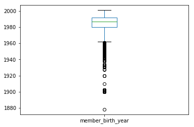

```python
df.member_birth_year.plot('box');
```

Although it seems very strange to have bike users over 100 years old, we lack information that confirms that these values are really wrong.

### 2. Data Cleaning

The dataset for bike rides requires cleaning for the following quality issues:

- Object data type values of datetime columns (**start_time** and **end_time**).
- Missing data of station identifiers and names (cannot be cleaned).
- Inaccurate values of latitudes and longitudes.
- The columns of the identifiers and the geographic coordinates are of numeric type.
- The **user_type**, **member_gender** and **bike_share_for_all_trip** columns have object type data.
- No data on member's gender and/or year of birth (cannot be cleaned).
- Users over the age of 100 (just noted).

Fortunately, there are no tidiness errors.

```python
# make a copy of the dataframe for cleaning
df_clean = df.copy()
```

#### Issue n°1: Object data type values of datetime columns

##### Define

**start_time** and **end_time** are two columns that indicate the start and end date and time of the trip. Changing the data type for them will help in future tasks.

##### Code

```python
df_clean[['start_time', 'end_time']] = df_clean[['start_time', 'end_time']].apply(pd.to_datetime)
```

##### Test

```python
df_clean[['start_time', 'end_time']].dtypes
```

```
start_time    datetime64[ns]
end_time      datetime64[ns]
dtype: object
```

#### Issue n°2: Inaccurate values of latitudes and longitudes

##### Define

For each trip, the geographic coordinates of the start and end point were used to determine the station name and station ID, but the dataset contains 197 records with imprecise latitude and longitude values, which which results in missing information on some stations. it would be better to change these values to null.

##### Code

```python
missing_data_mask = df_clean.start_station_id.isnull()
columns_to_change = ['start_station_latitude', 'start_station_longitude',
                    'end_station_latitude', 'end_station_longitude']

df_clean.loc[missing_data_mask, columns_to_change] = np.nan
```

##### Test

```python
df_clean.isnull().sum()
```

```
duration_sec                  0
start_time                    0
end_time                      0
start_station_id            197
start_station_name          197
start_station_latitude      197
start_station_longitude     197
end_station_id              197
end_station_name            197
end_station_latitude        197
end_station_longitude       197
bike_id                       0
user_type                     0
member_birth_year          8265
member_gender              8265
bike_share_for_all_trip       0
dtype: int64
```

#### Issue n°3: The columns of the identifiers and the geographic coordinates are of numeric type

##### Define

The data we find in these columns looks numerical whene it would be better to treat them as categorical.

##### Code

```python
cols_to_change = ['start_station_id', 'start_station_latitude',
                  'start_station_longitude', 'end_station_id',
                 'end_station_latitude', 'end_station_longitude',
                 'bike_id']
df_clean[cols_to_change] = df_clean[cols_to_change].astype('object')
```

##### Test

```python
df_clean.dtypes
```

```
duration_sec                        int64
start_time                 datetime64[ns]
end_time                   datetime64[ns]
start_station_id                   object
start_station_name                 object
start_station_latitude             object
start_station_longitude            object
end_station_id                     object
end_station_name                   object
end_station_latitude               object
end_station_longitude              object
bike_id                            object
user_type                          object
member_birth_year                 float64
member_gender                      object
bike_share_for_all_trip            object
dtype: object
```

#### Issue n°4: The **user_type**, **member_gender** and **bike_share_for_all_trip** columns have object type data.

##### Define

We saw earlier that these columns contain nominal data such as "Customer" and "Subscriber", "male" "female" and "other", "No" and "Yes". Changing their data type to category in Pandas may be helpful in future analysis.

##### Code

```python
cols_to_change = ['user_type', 'member_gender', 'bike_share_for_all_trip']
df_clean[cols_to_change] = df_clean[cols_to_change].astype('category')
```

##### Test

```python
df_clean.dtypes
```

```
duration_sec                        int64
start_time                 datetime64[ns]
end_time                   datetime64[ns]
start_station_id                   object
start_station_name                 object
start_station_latitude             object
start_station_longitude            object
end_station_id                     object
end_station_name                   object
end_station_latitude               object
end_station_longitude              object
bike_id                            object
user_type                        category
member_birth_year                 float64
member_gender                    category
bike_share_for_all_trip          category
dtype: object
```

### 3. Features Engineering

A final step before moving on to the analysis section is to make some changes and create new variables that will be easier to use for extracting information.

The following code blocks:

- Convert duration column from seconds to minutes.
- Extract the hour, day (name, working day or not) and city of departure and arrival of the bike ride.
- Calculate the age of the client.

```python
# convert duration from seconds to minutes
df_clean['duration_sec'] = round(df_clean['duration_sec'] / 60, 2)

# rename the column
df_clean.rename(columns = {'duration_sec': 'duration_min'}, inplace = True)
```

```python
# a function that extract the hour and day name from a given column
def hour_day_extract(dataframe, column):
    col_loc = dataframe.columns.get_loc(column) # get column location
    prefix = column.split("_")[0] # start or end
    # insert hour column
    dataframe.insert(col_loc + 1, prefix + "_hour", dataframe[column].dt.hour)
    # insert day name column
    dataframe.insert(col_loc + 2, prefix + "_day", dataframe[column].dt.day_name())
    # convert day name column to ordinal
    days_list = ['Monday', 'Tuesday', 'Wednesday', 'Thursday',
                'Friday', 'Saturday', 'Sunday']
    orderd_days = pd.api.types.CategoricalDtype(ordered = True, categories = days_list)
    dataframe[prefix + "_day"] = dataframe[prefix + "_day"].astype(orderd_days)
    # insert an indication for the weekend
    dataframe.insert(col_loc + 3, prefix + "_IsWeekend", dataframe[column].dt.day_name().isin(['Saturday', 'Sunday']))
```

```python
# extract hours and day names
for col in ['start_time', 'end_time']:
    hour_day_extract(df_clean, col)
```

```python
# extract cities
# get unique data for each station
stations_data = df_clean.groupby('start_station_id', as_index = False).first()
stations_data = stations_data[['start_station_id', 'start_station_latitude', 'start_station_longitude']]

# use reverse geocoding
cities_list = []
for ind, row in stations_data.iterrows():
    try:
        city = rg.search((row['start_station_latitude'], row['start_station_longitude']))[0]['name']
    except:
        city = np.nan

    stations_data.loc[ind, 'start_city'] = city

stations_data.head(10)
```

```
Loading formatted geocoded file...
```

|  | start_station_id | start_station_latitude | start_station_longitude | start_city |
| --- | --- | --- | --- | --- |
| 0 | 3.0 | 37.786375 | -122.404904 | San Francisco |
| 1 | 4.0 | 37.785881 | -122.408915 | San Francisco |
| 2 | 5.0 | 37.783899 | -122.408445 | San Francisco |
| 3 | 6.0 | 37.804770 | -122.403234 | San Francisco |
| 4 | 7.0 | 37.804562 | -122.271738 | Oakland |
| 5 | 8.0 | 37.799953 | -122.398525 | San Francisco |
| 6 | 9.0 | 37.798572 | -122.400869 | San Francisco |
| 7 | 10.0 | 37.795393 | -122.404770 | San Francisco |
| 8 | 11.0 | 37.797280 | -122.398436 | San Francisco |
| 9 | 13.0 | 37.794231 | -122.402923 | San Francisco |

```python
# select data to add to the bikes dataframe
stations_data = stations_data[['start_station_id', 'start_city']].astype('object')

# add start cities
df_clean = df_clean.merge(right = stations_data,
                          how = 'left',
                          on = 'start_station_id')

# rename columns to fcilitates merging for end stations
stations_data.columns = stations_data.columns.str.replace('start', 'end')

# add end cities
df_clean = df_clean.merge(right = stations_data,
                          how = 'left',
                          on = 'end_station_id')
```

```python
# calculate the age of the client
df_clean['member_birth_year'] = 2019 - df_clean['member_birth_year']

# rename the column
df_clean.rename(columns = {'member_birth_year': 'member_age'}, inplace = True)
```

```python
# check results
df_clean.sample(3)
```

|  | duration_min | start_time | start_hour | start_day | start_IsWeekend | end_time | end_hour | end_day | end_IsWeekend | start_station_id | ... | end_station_name | end_station_latitude | end_station_longitude | bike_id | user_type | member_age | member_gender | bike_share_for_all_trip | start_city | end_city |
| --- | --- | --- | --- | --- | --- | --- | --- | --- | --- | --- | --- | --- | --- | --- | --- | --- | --- | --- | --- | --- | --- |
| 140756 | 17.15 | 2019-02-07 18:31:17.371 | 18 | Thursday | False | 2019-02-07 18:48:27.298 | 18 | Thursday | False | 67 | ... | Sanchez St at 15th St | 37.7662 | -122.431 | 4799 | Subscriber | 28.0 | Male | No | San Francisco | San Francisco |
| 116423 | 13.57 | 2019-02-12 07:43:42.722 | 7 | Tuesday | False | 2019-02-12 07:57:16.813 | 7 | Tuesday | False | 109 | ... | San Francisco Caltrain Station 2 (Townsend St... | 37.7766 | -122.396 | 1012 | Subscriber | 32.0 | Female | No | San Francisco | San Francisco |
| 133625 | 20.78 | 2019-02-08 18:26:19.284 | 18 | Friday | False | 2019-02-08 18:47:06.995 | 18 | Friday | False | 153 | ... | Milvia St at Derby St | 37.8601 | -122.269 | 5433 | Subscriber | 21.0 | Female | No | Emeryville | Berkeley |

3 rows × 24 columns

```python
# select final dataframe
cols_to_keep = ['duration_min', 'start_hour', 'start_day',
               'start_IsWeekend', 'start_station_name', 'start_city',
               'end_hour', 'end_day', 'end_IsWeekend', 'end_station_name',
               'end_city', 'bike_id', 'bike_share_for_all_trip',
               'user_type', 'member_age', 'member_gender']

bikes_df = df_clean[cols_to_keep]
bikes_df.head()
```

|  | duration_min | start_hour | start_day | start_IsWeekend | start_station_name | start_city | end_hour | end_day | end_IsWeekend | end_station_name | end_city | bike_id | bike_share_for_all_trip | user_type | member_age | member_gender |
| --- | --- | --- | --- | --- | --- | --- | --- | --- | --- | --- | --- | --- | --- | --- | --- | --- |
| 0 | 869.75 | 17 | Thursday | False | Montgomery St BART Station (Market St at 2nd St) | San Francisco | 8 | Friday | False | Commercial St at Montgomery St | San Francisco | 4902 | No | Customer | 35.0 | Male |
| 1 | 708.68 | 18 | Thursday | False | The Embarcadero at Steuart St | San Francisco | 6 | Friday | False | Berry St at 4th St | San Francisco | 2535 | No | Customer | NaN | NaN |
| 2 | 1030.90 | 12 | Thursday | False | Market St at Dolores St | San Francisco | 5 | Friday | False | Powell St BART Station (Market St at 4th St) | San Francisco | 5905 | No | Customer | 47.0 | Male |
| 3 | 608.17 | 17 | Thursday | False | Grove St at Masonic Ave | San Francisco | 4 | Friday | False | Central Ave at Fell St | San Francisco | 6638 | No | Subscriber | 30.0 | Other |
| 4 | 26.42 | 23 | Thursday | False | Frank H Ogawa Plaza | Oakland | 0 | Friday | False | 10th Ave at E 15th St | Oakland | 4898 | Yes | Subscriber | 45.0 | Male |

### 4. Summary

My interest in this notebook is to find out which factors influence the duration of the bike ride and where and when there is a greater bike usage.

I mainly think the day and time of the journey affect the duration, for example I expect to have shorter journeys on weekdays but higher use of the bikes on weekends. I also want to know the effect of departure and arrival points (station and/or city) and available user data on the feature I'm interested in.

## II. Univariate Exploration

In this section, I'll investigate distributions of individual variables. Let's start by looking at the main variable of interest: Duration

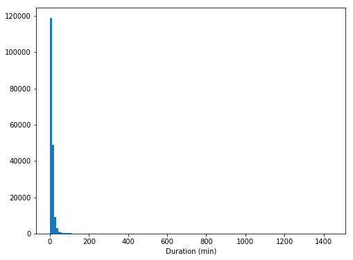

```python
bins = np.arange(1, 1425 + 20, 10)

plt.figure(figsize = (8, 6))
plt.hist(data = bikes_df, x = 'duration_min', bins = bins)
plt.xlabel('Duration (min)')
plt.show()
```

The graph above shows that the vast majority of bike rides are less than 30 minutes, one potential explanation is that bikes were mainly used for daily transport. The duration distribution has a very long tail on the right side, some bikes have been used for about a day, so let's put it on a logarithmic scale:

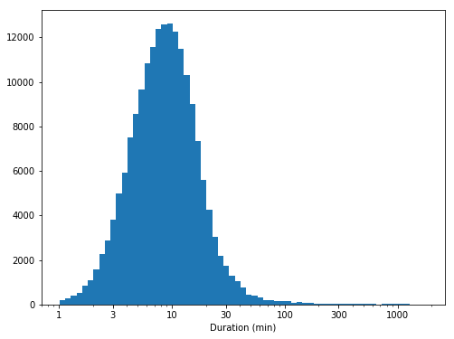

```python
bins = 10**np.arange(0.007, 3.16 + 0.1, 0.05)

plt.figure(figsize = (8, 6))
plt.hist(data = bikes_df, x = 'duration_min', bins = bins)
plt.xscale('log')
xticks = [1, 3, 10, 30, 100, 300, 1000]
plt.xticks(xticks, xticks)
plt.xlabel('Duration (min)')
plt.show()
```

Plotting on a logarithmic scale the distribution of durations looks normal now, the majority of journeys are around 10 minutes long, we have a few durations of one to two minutes on one side and over two hours to a day on the other side.

Next, I want to study time-related variables:

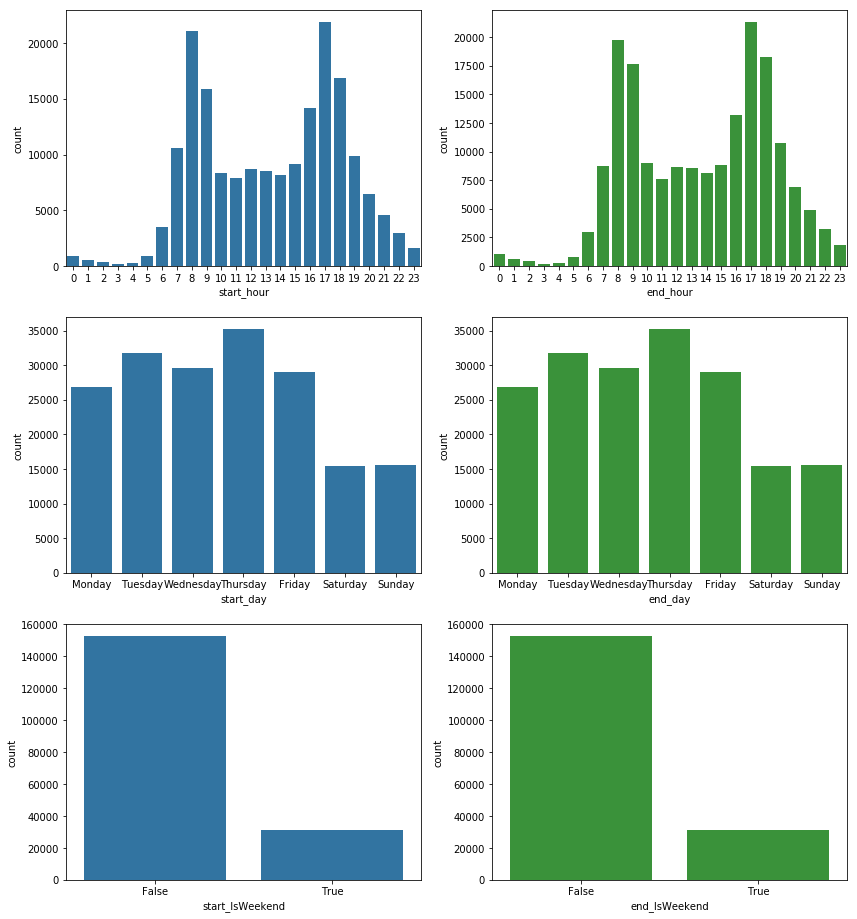

```python
cols_to_plot = ['start_hour', 'start_day', 'start_IsWeekend',
               'end_hour', 'end_day', 'end_IsWeekend']

fig, ax = plt.subplots(ncols = 2, nrows = 3 , figsize = [14,16])
default_color1 = sb.color_palette()[0]
default_color2 = sb.color_palette()[2]

for i in range(3):
    start_var = cols_to_plot[i]
    sb.countplot(data = bikes_df, x = start_var, color = default_color1, ax = ax[i, 0])

    end_var = cols_to_plot[i + 3]
    sb.countplot(data = bikes_df, x = end_var, color = default_color2, ax = ax[i, 1])

plt.show()
```

The first thing to spot is that the data distribution is very similar between the start time of the bike ride and its end time, this is quite understandable considering that around 96% of the rides in the dataset last less than half an hour, which means that in most cases the bike was picked up and returned in the same hour and the same day.

On the other hand, we note that the bicycles were heavily used during the week, especially around the hours of going to work or returning home.

Knowing this, my attention now is to see if the bikes at certain stations are heavily used rather than others. I'll start by plotting the locations of the stations on the map of San Francisco:

```python
# get unique data for each station
stations_data = df_clean.groupby('start_station_name', as_index = False).first()
stations_data = stations_data[['start_station_name', 'start_station_latitude', 'start_station_longitude']]

labels = stations_data.start_station_name
latitudes = stations_data.start_station_latitude
longitudes = stations_data.start_station_longitude

# create San Francisco map
sanfran_map = folium.Map(location = (37.80, -122.35), zoom_start = 12)

# loop through the 329 stations and add each to the stations feature group
for lat, lng, label in zip (latitudes, longitudes, labels):
    folium.features.CircleMarker(
        [lat, lng],
        radius = 5,
        color = 'yellow',
        fill = True,
        popup = label,
        fill_color = 'blue',
        fill_opacity = 0.6
    ).add_to(sanfran_map)

sanfran_map
```

Make this Notebook Trusted to load map: File -> Trust Notebook

[interactive chart not shown]

We can see here that although the dataset covers the greater San Francisco Bay Area, which explains the short ride times, some riders went too far in other cities like Berkeley, Emeryville, Oakland, etc Here is the breakdown of cities:

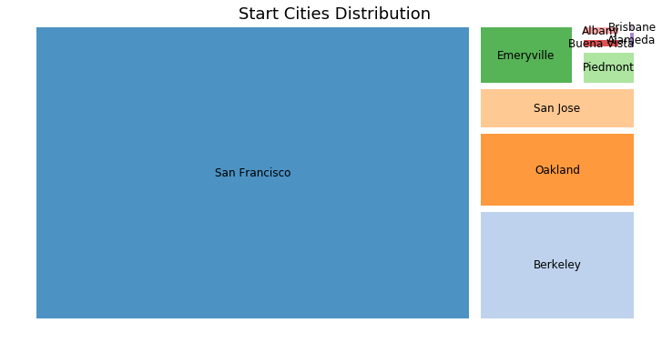

```python
plt.figure(figsize = (12, 6))

start_cities_counts = bikes_df['start_city'].value_counts()

squarify.plot(sizes = start_cities_counts,
              label = start_cities_counts.index,
              color = sb.color_palette("tab20", len(start_cities_counts)),
              pad = 1,
              alpha=.8,
             text_kwargs={'fontsize': 12})
plt.axis('off')
plt.title('Start Cities Distribution', fontsize = 18)
plt.show()
```

Now that I know that the majority of bike rides started from San Francisco, I want to check if there were any rides that started from one city and ended in another:

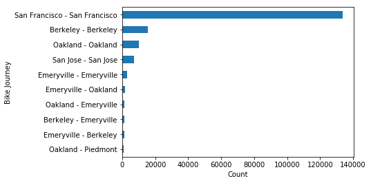

```python
# plot top 10 journeys made between cities
plt.figure(figsize = [6, 4])

cities_journey = (bikes_df['start_city'] + " - " + bikes_df['end_city']).value_counts()

cities_journey.head(10).sort_values().plot(kind = 'barh', color = default_color1)
plt.xlabel('Count')
plt.ylabel('Bike Journey')
plt.show()
```

About 90% of bicycle journeys were made between stations in the same city.

Let's do the same and check which stations have the most trips made in both directions.

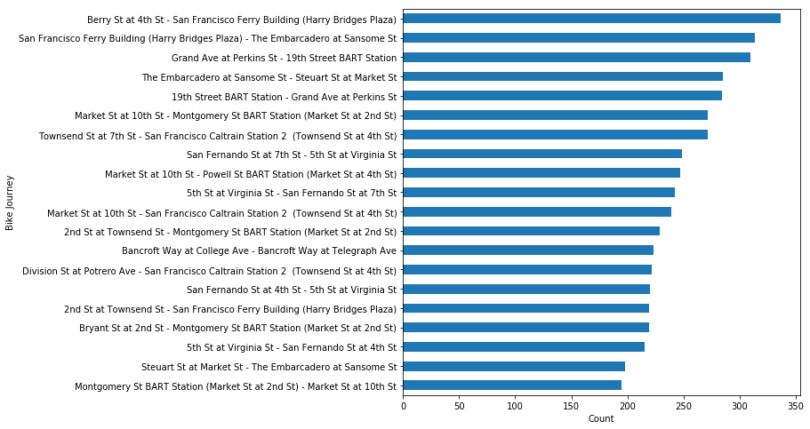

```python
# plot top 20 journeys made between stations
plt.figure(figsize = [8, 8])

stations_journey = (bikes_df['start_station_name'] + " - " + bikes_df['end_station_name']).value_counts()

stations_journey.head(20).sort_values().plot(kind = 'barh', color = default_color1)
plt.xlabel('Count')
plt.ylabel('Bike Journey')
plt.show()
```

Some paths are more frequent than others in this database, the location of the station certainly has an important effect on the use of bicycles.

We have a feature in the dataset that shows if the bike is shared for all rides, let's explore it:

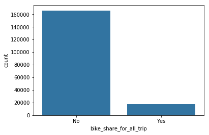

```python
sb.countplot(data = bikes_df, x = 'bike_share_for_all_trip',
            color = default_color1)
plt.show()
```

The bar graph above shows that a low number of bikes are part of a ride schedule.

Before closing this section, let's take a look at the user-related variables:

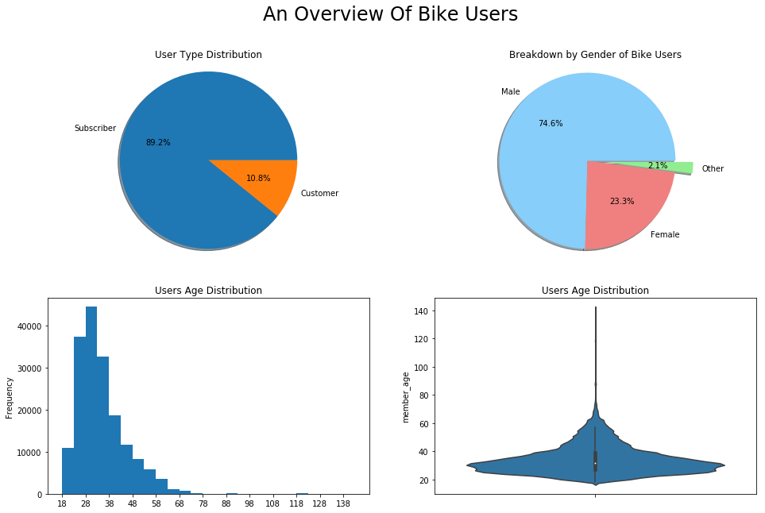

```python
fig = plt.figure(figsize = (16, 10))

# plot user type distribution
ax1 = fig.add_subplot(221)
bikes_df.user_type.value_counts().plot(kind = 'pie',
                                      autopct = '%1.1f%%',
                                      shadow = True,
                                      ax = ax1)
ax1.axis('equal')
ax1.set(ylabel = '', title = 'User Type Distribution')

# plot gender distribution
ax2 = fig.add_subplot(222)
bikes_df.member_gender.value_counts().plot(kind = 'pie',
                                      autopct = '%1.1f%%',
                                      shadow = True,
                                      explode = [0, 0, 0.2],
                                      colors = [ 'lightskyblue', 'lightcoral', 'lightgreen'],
                                      ax = ax2)
ax2.axis('equal')
ax2.set(ylabel = '', title = 'Breakdown by Gender of Bike Users')

# plot a histogram for members age
ax3 = fig.add_subplot(223)
bins = np.arange(bikes_df.member_age.min(), bikes_df.member_age.max() + 5, 5)
xticks = bins[list(range(0, len(bins), 2))]
bikes_df.member_age.plot(kind = 'hist',
                         bins = bins,
                         xticks = xticks,
                         ax = ax3)
ax3.set_title('Users Age Distribution')

# plot a violinplot for members age
ax4 = fig.add_subplot(224)
sb.violinplot(data = bikes_df,
             y = 'member_age',
             ax = ax4)
ax4.set_title('Users Age Distribution')

plt.suptitle('An Overview Of Bike Users', fontsize = 24)
plt.show()
```

Looking at the user data available in the dataset, I can see that the top users of the bikes available through this system are subscribers. It's quite understandable that people who use these bikes frequently tend to subscribe. It is also quite remarkable that men are the sex that uses this bike more than the others. Young people also seem to prefer this transport tool.

### Univariate Exploration Summary

> The main variable I was looking for is duration, it had a wide range of values from a minute to almost a day. With a logarithmic transformation, the data appeared normal with a peak around 10 minutes. We found that 96% of trips were less than half an hour.

## III. Bivariate Exploration

For the beginning of this section, I'll look at the relationships between three important variables: duration, start day, and start hour.

So first, which day(s) and time(s) have the most bike usage?

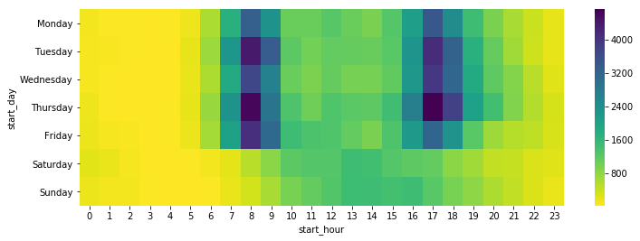

```python
# create a pivot table with the bikes count for each hour-day combination
temp = bikes_df.groupby(['start_hour', 'start_day']).size()
temp = temp.reset_index().pivot(index = 'start_day', columns = 'start_hour')
temp.columns = temp.columns.droplevel()

# plot a hatmap
plt.figure(figsize = (12, 4))
sb.heatmap(temp, cmap = 'viridis_r')
plt.show()
```

Well it's no wonder users start using these bikes early in the morning during the week, the usage numbers peak around 8am (about 4500 bikes are in use) the rest of the day has a number average number of bikes used per hour (between 800 and 2000) and keep going until evening comes and people start coming home from work. Weekends are a bit different, times between 12pm and 5pm have the most bikes in circulation.

Knowing the effect of time on bicycle use, do these features affect ride time?

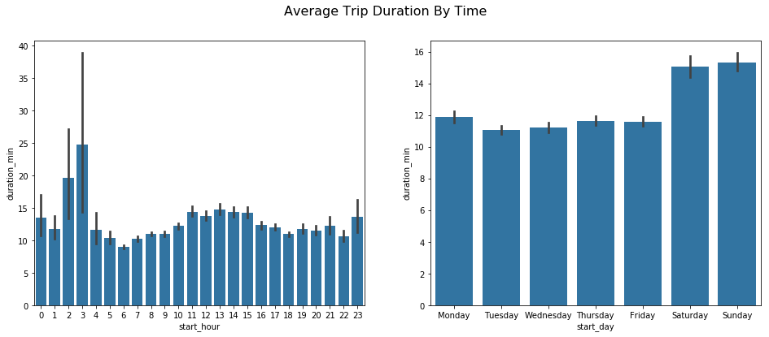

```python
# barplots of the average duration by hour and by day
fig = plt.figure(figsize = (16, 6))

for i, col in enumerate(["start_hour", "start_day"]):
    ax = fig.add_subplot(1, 2, i+1)

    sb.barplot(data = bikes_df, x = col, y = "duration_min",
           color = default_color1, estimator = np.mean)


plt.suptitle('Average Trip Duration By Time', fontsize = 16)
plt.show()
```

If we consider that the day starts at 6 a.m., the average trip time continues to increase over time and it decreases a little in the evening, on the other hand the longest ones were recorded during the night. the graph on the right shows a different trend of trip duration versus bike use over the week days, weekends have the longest bike trips on average.

Now that we know the effect of time on the use of bicycles, can we expect it to also have an effect on the journeys made by users? For the following code cell, I'm going to list the top 3 routes cyclists take each day, group them, and then plot a bar graph to see how the routes cyclists take change from day to day:

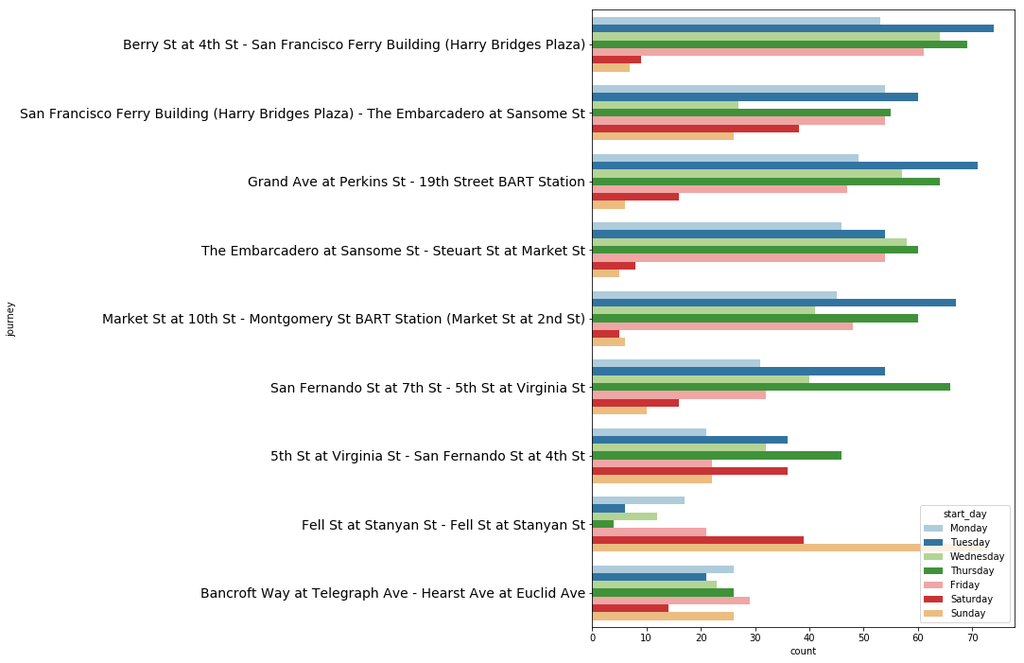

```python
# create a new column called journey
bikes_df['journey'] = bikes_df['start_station_name'] + " - " + bikes_df['end_station_name']

# idnetify the top 3 routes for each day and group them in one list
top_journ = []
for day in bikes_df.start_day.unique():
    stations = bikes_df.loc[bikes_df.start_day == day, 'journey'].value_counts().head(3).index
    top_journ.extend(stations)

# eliminate duplicates
top_journ = list(set(top_journ))

# make a bar plot
plt.figure(figsize = (8, 12))
ax = sb.countplot(data = bikes_df,
                  y = 'journey',
                  hue = 'start_day',
                  order = bikes_df.loc[bikes_df.journey.isin(top_journ), 'journey'].value_counts().index,
                  palette = 'Paired')

ylabels = ax.yaxis.get_majorticklabels()
ax.set_yticklabels(ylabels, fontsize = 14)
plt.show()
```

The graph above shows the number of users for nine different circuits each day of the week. Each of these circuits appeared at least once in the first three rides of each day. We can clearly observe that the first six circuits are mainly done during the week, while for Sunday the inhabitants of San Francisco rather prefer the station of "Fell St at Stanyan St", it is a station very close to Golden Park. For me I tend to think that the rides in the park are very popular on weekends.

Speaking of users, let's look at the relationships between the three available variables of our riders and our variable duration.

Since the age column has extreme values, I'll make it categorical with three levels: young, middle-aged, and old:

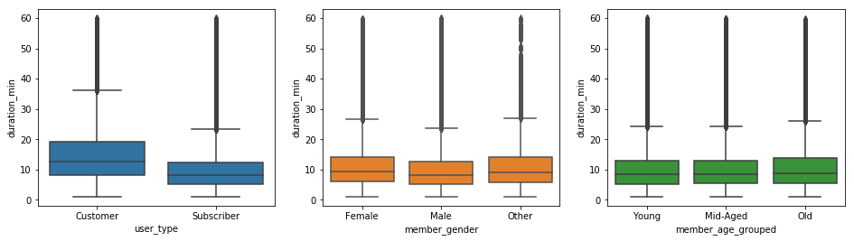

```python
# group members by age
bikes_df['member_age_grouped'] = pd.cut(x = bikes_df.member_age,
                                        bins = [18, 30, 45, max(bikes_df.member_age)],
                                        labels = ['Young', 'Mid-Aged', 'Old'],
                                        include_lowest = True
                                        )

# plot boxplots for each graph
fig, ax = plt.subplots(1, 3, figsize = (16, 4))

for i, col in enumerate(['user_type', 'member_gender', 'member_age_grouped']):
    sb.boxplot(data = bikes_df.query("duration_min <= 60"),
               x = col,
               y = 'duration_min',
               ax = ax[i],
               color = sb.color_palette()[i]
              )
```

Selecting only rows where the journey time is less than or equal to one hour, we find that customers tend to take longer bike trips than subscribers. The chart on the left shows that half of customer trips were 12 minutes or less, while for subscribers, 75% of trips were less than or equal to that. In contrast, there was no such relationship between members' sex, age group and duration.

### Bivariate Exploration Summary

> The duration of the journey is quite correlated with the hour and the day. We have seen through the barplots how the average duration keeps changing with the hours of the day. Longer journeys are made during the weekend, and interestingly by customers.

> On the other hand, we have seen how the use of bicycles differs from hour to hour and from day to day, mornings and evenings of the week have a large peak in the use of bicycles. Additionally, the routes that bike users take tend to change daily, especially on weekends, when San Francisco locals prefer to ride around the park.

## IV. Multivariate Exploration

In this section, I want to explore how the duration of rides changes as a function of time and day, and then as a function of the three user-related variables.

To start, I'll only select rows with ride times of 60 minutes or less:

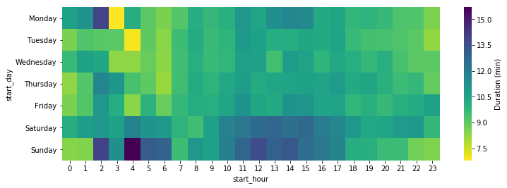

```python
# select rows with duration equal or less to 1 hour
less60_df = bikes_df.query("duration_min <= 60")

# create a pivot table with the average ride durationfor each hour-day combination
temp = less60_df.groupby(['start_hour', 'start_day'])[['duration_min']].mean()
temp = temp.reset_index().pivot(index = 'start_day', columns = 'start_hour')
temp.columns = temp.columns.droplevel()

# plot a heatmap
plt.figure(figsize = (12, 4))
sb.heatmap(temp, cmap = 'viridis_r', cbar_kws={'label': 'Duration (min)'})
plt.show()
```

The darker dots in the above heatmap indicate the average of the highest durations. Surprisingly, early Sunday mornings have the highest values, but in general the longest trips are made on weekends from 10 a.m. to 5 p.m.

Now for the users features:

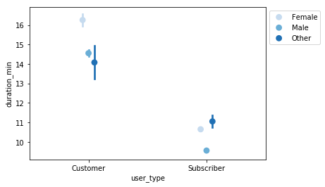

```python
plt.figure(figsize = (6, 4))

sb.pointplot(data = less60_df, x = 'user_type', y = 'duration_min', hue = 'member_gender',
            palette = 'Blues', linestyles = '', dodge = 0.1)

plt.legend(loc='upper left', bbox_to_anchor=(1, 1))
plt.show()
```

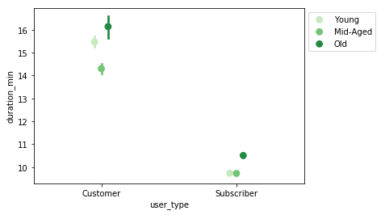

```python
plt.figure(figsize = (6, 4))

sb.pointplot(data = less60_df, x = 'user_type', y = 'duration_min', hue = 'member_age_grouped',
            palette = 'Greens', linestyles = '', dodge = 0.1)

plt.legend(loc='upper left', bbox_to_anchor=(1, 1))
plt.show()
```

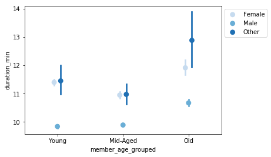

```python
plt.figure(figsize = (6, 4))

sb.pointplot(data = less60_df, x = 'member_age_grouped', y = 'duration_min', hue = 'member_gender',
            palette = 'Blues', linestyles = '', dodge = 0.1)

plt.legend(loc='upper left', bbox_to_anchor=(1, 1))
plt.show()
```

It turns out that the gender of users has an influence on the duration of journeys, with female customers making the longest journeys where male subscribers register the lowest average duration. Men also make the shortest journeys across all three age categories, and we find that older people have longer journey times across customer and subscriber categories.

### Multivariate Exploration Summary

> The time-day combination not only has an influence on the use of bicycles, but also on the duration of journeys. While users take shorter trips on weekdays, they prefer to take longer bike rides on weekends in the early morning and mid-day.

> Another interesting finding is how the interaction between the three user-related variables influences trip duration. Regardless of the age category, the men's bike rides are very short, where the female clientele tends to be longer.

## V. Conclusions

In this notebook, I analyzed the bike trip data provided by Ford GoBike System, mainly we had 183,412 trips divided into 16 different columns. The data required cleaning and transformation, after which I proceeded to the exploration phase.

Bike trip data was primarily collected from stations in San Francisco, with other trips taken in nearby cities like Berkeley, Oakland, Emeryville, etc. This bike sharing system is mainly used by subscribers, men and young users.

The main variable of interest is Duration, I discovered, with logarithmic transformation, that most recorded bike rides lasted less than half an hour, with a peak around ten minutes.

I was also interested in the evolution of hourly and daily bicycle use, weekdays and times when people tend to commute from home to work and vice versa had the highest use of bicycles. On the other side, weekeends have the greatest average bike rides duration, especially in the middle of the day.

Finally, I found that the longest bike trips are associated with customers, especially female customers and old customers, men on the other hand make very short trips on average for different age categories.